# The Enemy Ship Game World

In this lesson, we’ll see how to integrate a sub-window into our game world for the enemy AI ship. We’ll set up a separate game space to render the enemy ship and its surroundings using the

[figure not shown]

`Viewport` node.

Like split-screen views, using a viewport like this suggests a large distance between the player and enemy ships, as seen in Faster Than Light.

Besides adding a distinct flavor to our gameplay, we also need this to work before we can cover the weapons system.

The weapons system depends on the sub-window as projectiles and lasers have to pass from the player game space into the enemy AI ship game space and vice versa.

## The enemy AI ship

First, we need a ship to populate the viewport we’ll create. This is the perfect opportunity to design another ship that we’ll use as the enemy AI.

Go to *Scene -> New Inherited Scene…* and create a new inherited scene from `ShipTemplate.tscn`, just like we did for *ShipPlayer*.

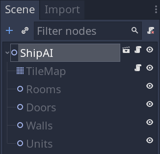

Rename the root node to *ShipAI* and save the scene at `res://TacticalSpaceCombat/Ship/ShipAI.tscn`.

Like we did for *ShipPlayer* in a previous lesson, construct a ship to your liking. To keep it simple, I’m going to go with this setup with two rooms and one door:

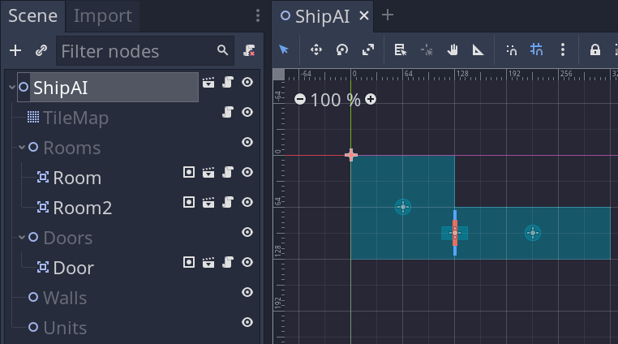

To do this, I instantiated `Room.tscn` twice under the *Rooms* node and `Door.tscn` under the *Doors* node by pressing `Ctrl`+`Shift`+`A`.

The first *Room* has a *Size* of `2` by `2` and the other has a *Size* of `3` by `1`.

## Setting up the viewport

Next, we’ll set up a new

[figure not shown]

`Viewport` to display our *ShipAI*. Viewports represent views through which a game engine renders geometry.

Godot always creates one that renders your game by default: the root

[figure not shown]

`Viewport` node. You can see it by running your game and clicking the *Remote* tab in the *Scene* dock.

[figure not shown]

Let’s add our

[figure not shown]

`Viewport`. To do so, we need to go back to `TacticalSpaceCombat.tscn`.

A

[figure not shown]

`Viewport` node itself doesn’t display anything. It only tells Godot to render its contents to a separate image.

To view the contents of a

[figure not shown]

`Viewport` node in our game space, you can make it a child of a

[figure not shown]

`ViewportContainer`. Bearing that in mind, add the following new nodes to the scene:

[figure not shown]

- `ViewportContainer`.

[figure not shown]

  - `Viewport`.
    - An instance of `ShipAI.tscn`.

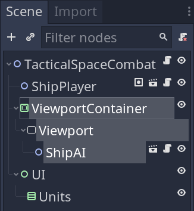

That way, the viewport will render its child, *ShipAI*.

For

[figure not shown]

`ViewportContainer` change the following settings in the *Inspector*:

- *Rect -> Position* to `1024` by `128` to shift the enemy view to the right of the game window.
- *Rect -> Size* to `768` by `832` to have a picture-in-picture effect.

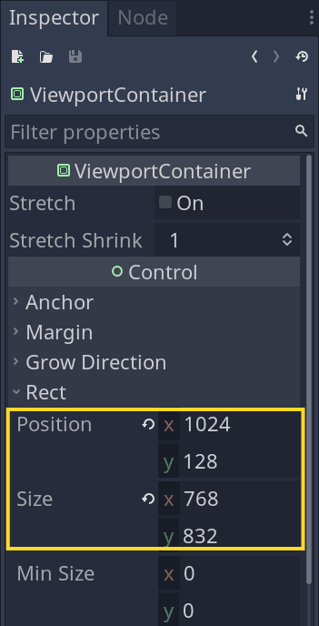

Also set the *Mouse -> Filter* to *Ignore* so the node doesn’t block mouse clicks.

We need this to make room highlighting work when hovering the mouse over them, just like it works for the player ship.

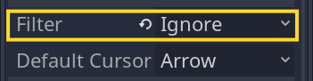

For

[figure not shown]

`Viewport`, change the following properties:

- Set its *Size* to `768` by `832` to match the parent container. This is the resolution at which the viewport renders a texture while the parent container displays it.
- Enable *Physics -> Object Picking*. We need this for mouse detection when hovering over rooms. Otherwise, the

[figure not shown]

  `Area2D` mouse interaction isn’t detected.

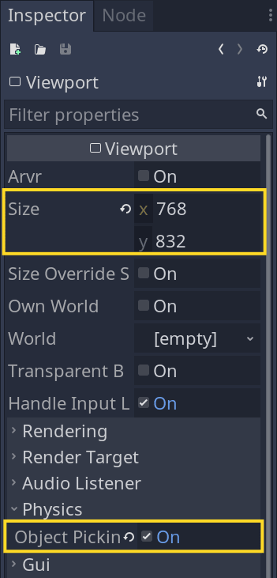

Finally, change the position of *ShipAI* to center it a bit in the

[figure not shown]

`Viewport`.

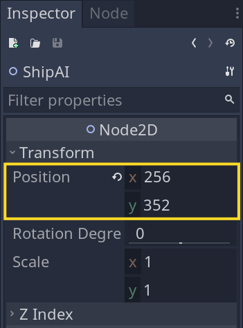

To see the ship in the editor, you’ll need to save your scene and click *Scene -> Reload Saved Scene*.

I ended up with this placement. Your game might look different but you should see both ships.

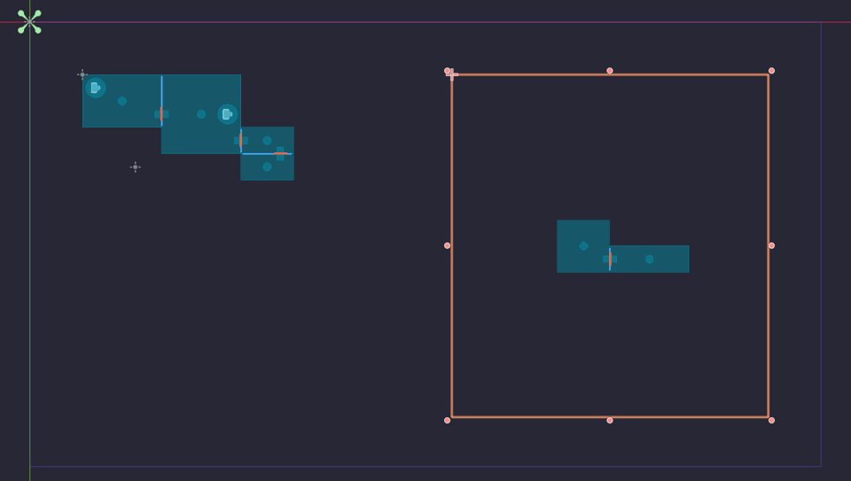

*Note* that, at the time of this writing, to change the position of the *ShipAI* node, you have to change the *Inspector Position* property directly. For now, Godot doesn’t offer a way to position nodes with the mouse in the editor’s 2D area if they’re children of a

[figure not shown]

`Viewport` node. This is a known limitation.

## Loose ends: ShipAI-player interactions

By adding *ShipAI* to the mix, we introduced a problem. If you run the code now, you can issue move commands to the ship player units by `RMB` clicking on rooms in the enemy ship viewport.

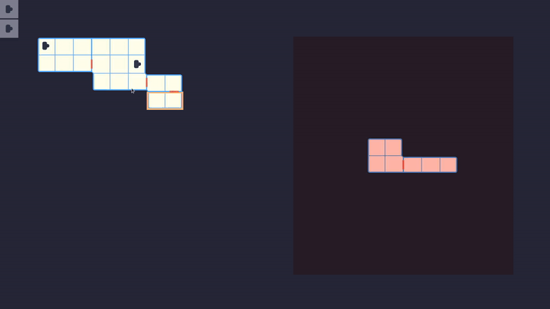

*Note* that I gave a slight pink tint to the

[figure not shown]

`Viewport` so it’s easy to distinguish in the video.

We don’t want this behavior so let’s fix it. Open the `ShipTemplate.gd` script file and make the following changes in the `_unhandled_input()` function:

```
func _unhandled_input(event: InputEvent) -> void:
        # ...
        # for room in get_tree().get_nodes_in_group("selected-room"):
            # We ensure the room is part of the player ship by checking the ship is in the `player` group.
            if not room.owner.is_in_group("player"):
                break

            # var point2: Vector2 = room.get_slot(_slots, unit)
            # ...
```

Remember that when we first created the *ShipPlayer* scene file, we added the *ShipPlayer* node to the `player` group. We’re using it here to skip player interaction with the enemy AI ship.

If you now run the main scene (`F5`), you should get the expected behavior without the player being able to move units by `RMB` clicking on the enemy ship rooms.

## Conclusion

In this lesson, we saw how to use the

[figure not shown]

`Viewport` node to create a sub-window showing the enemy AI ship in an independent game world.

We fixed a problem we introduced as a result of this new setup: restricting player interaction with the enemy ship, so units don’t move when clicking with `RMB` in any enemy ship rooms.

## Code reference

`res://TacticalSpaceCombat/Ship/ShipTemplate.gd`:

```
tool
class_name ShipTemplate
extends Node2D

var _slots := {}

onready var tilemap: TileMap = $TileMap
onready var rooms: Node2D = $Rooms
onready var doors: Node2D = $Doors
onready var units: Node2D = $Units


func _ready() -> void:
    call("_ready_editor_hint" if Engine.editor_hint else "_ready_not_editor_hint")


func _ready_editor_hint() -> void:
    for room in rooms.get_children():
        room.setup(tilemap)


func _ready_not_editor_hint() -> void:
    for unit in units.get_children():
        for door in doors.get_children():
            door.connect("opened", unit, "set_is_walking", [true])

        var position_map := tilemap.world_to_map(unit.path_follow.position)
        _slots[position_map] = unit

    for room in rooms.get_children():
        room.setup(tilemap)
        for point in room:
            tilemap.set_cellv(point, 0)
    tilemap.setup(rooms, doors)


func _unhandled_input(event: InputEvent) -> void:
    if not event.is_action_pressed("right_click"):
        return

    for unit in get_tree().get_nodes_in_group("selected-unit"):
        var point1: Vector2 = tilemap.world_to_map(unit.path_follow.position)
        for room in get_tree().get_nodes_in_group("selected-room"):
            if not room.owner.is_in_group("player"):
                break

            var point2: Vector2 = room.get_slot(_slots, unit)
            if is_inf(point2.x):
                break

            var path: Curve2D = tilemap.find_path(point1, point2)
            Utils.erase_value(_slots, unit)
            _slots[point2] = unit
            unit.walk(path)
```